# Visualization

We’ll be using three datasets today for our analysis:

```r
library(sf)
library(tidyverse)

# remember to remove quiet=T if you have trouble!
weca = st_read('../data/weca.gpkg', quiet=T)
earnings = read_csv('../data/earnings.csv')
temps = read_csv('../data/bristol_temps.csv') %>%
          pivot_longer(jan:dec, names_to='month', values_to='temperature') %>%
          mutate(month = ordered(month, levels=c("jan", "feb", "mar", "apr",
                                                 "may", "jun", "jul", "aug", "sep",
                                                 "oct", "nov", "dec")))
```

# 1 Visual Narratives

For each pair of visualizations, tell me:

1. **Which version emphasizes what information?** Questions that may help you scaffold this are:
- what visual variables (like color, shape) are varied in the plot?
- what scales or transformations are applied in the plot?
- what coordinate systems/facets are used, and how do these encourage comparisons?
2. **Which plot is the most effective at presenting this information and why?** Questions that may help you scaffold this discussion are:
- what visual variables change most dramatically?
- if you were to explain what the plot is showing to a friend, what would you say and why?
- which one do you find the most aesthetically pleasing? why?

## 1.1

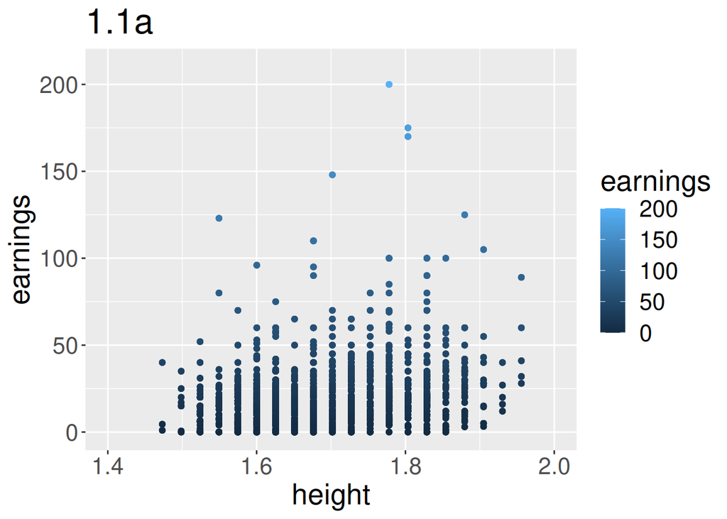

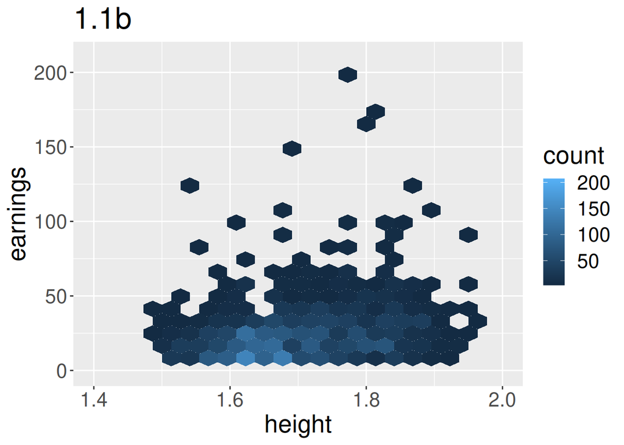

## 1.2

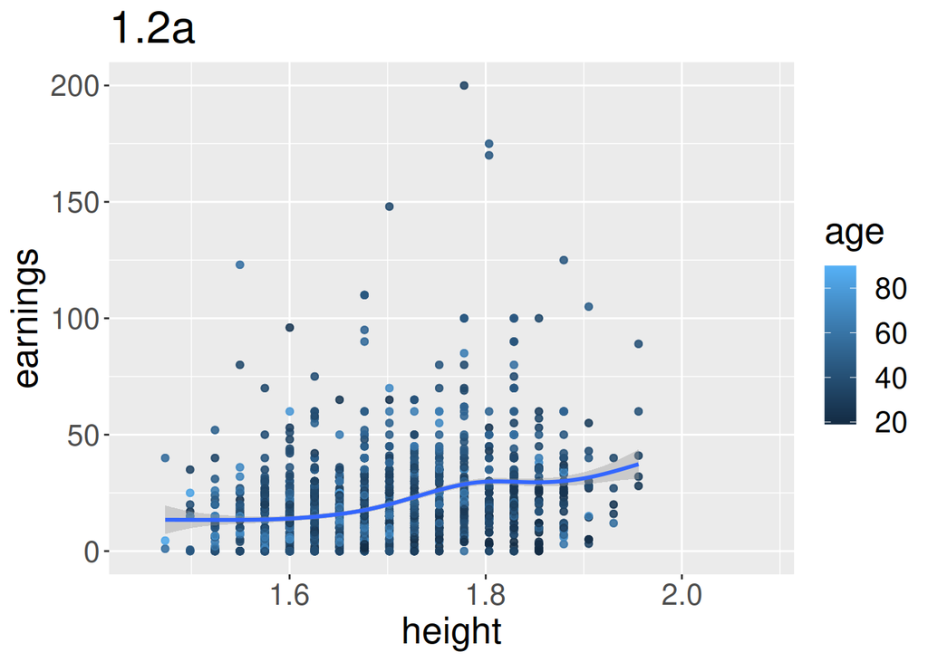

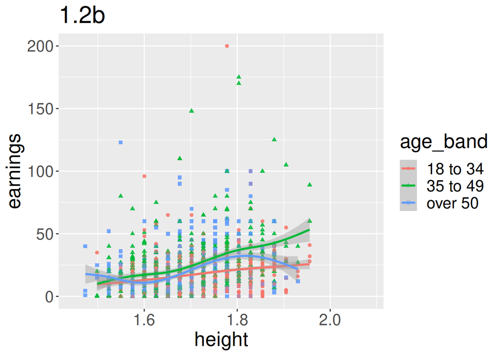

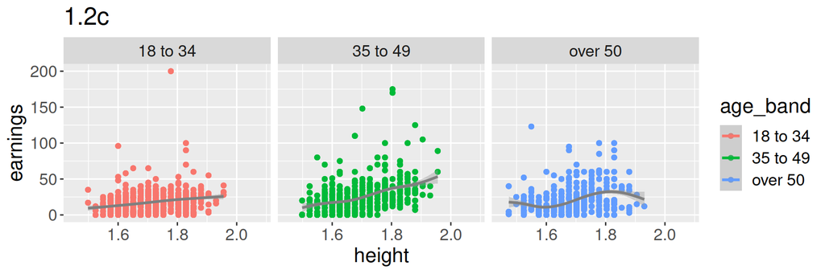

## 1.3

The following plot shows the average temperature every month, for every year of temperatures measured in a Bristol weather station, as well as the average curve for all years.

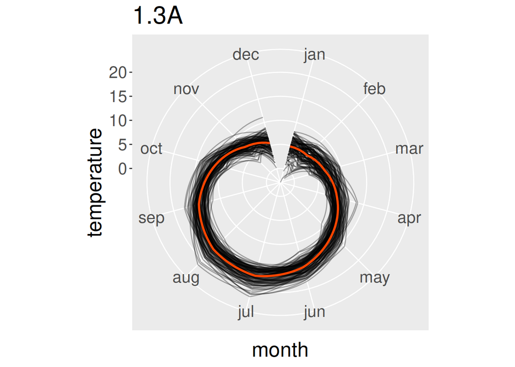

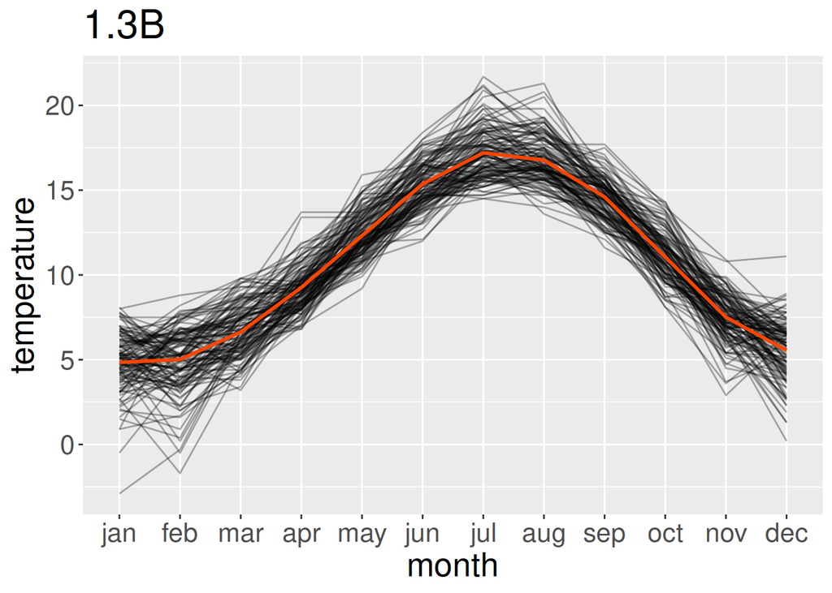

## 1.4

The following maps show the change in house prices since the global financial crisis. Specifically, it shows whether an LSOA’s house prices were among the top 25% most expensive in Bristol in 2006 (before) and 2018 (after) the crisis. If it was expensive both times, it is marked as a “stable at the top” area. If it was *not* in the top 25% most expensive areas both times, then it is marked as “stable at the bottom.” If it fell from the top 25%, then it is marked as “falls down,” and likewise for “rises up” being those areas that *entered* the top 25% most expensive areas after the crisis, but were not expensive before the crisis.

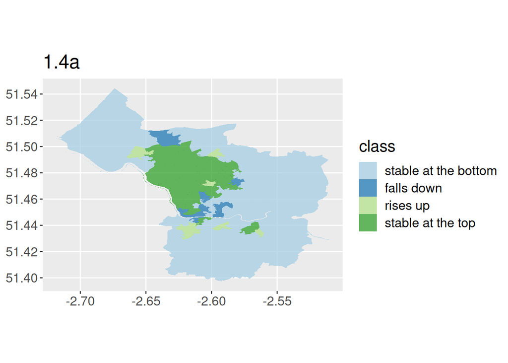

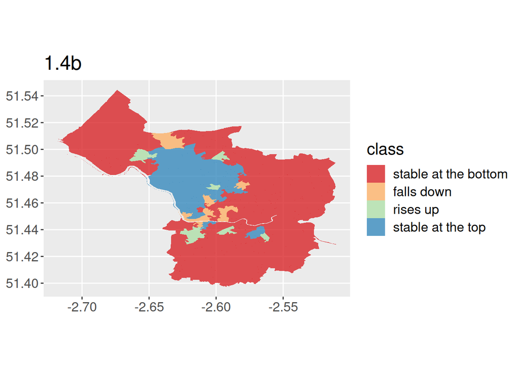

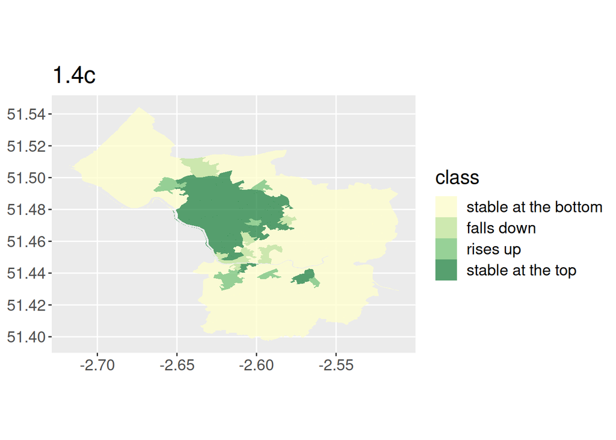

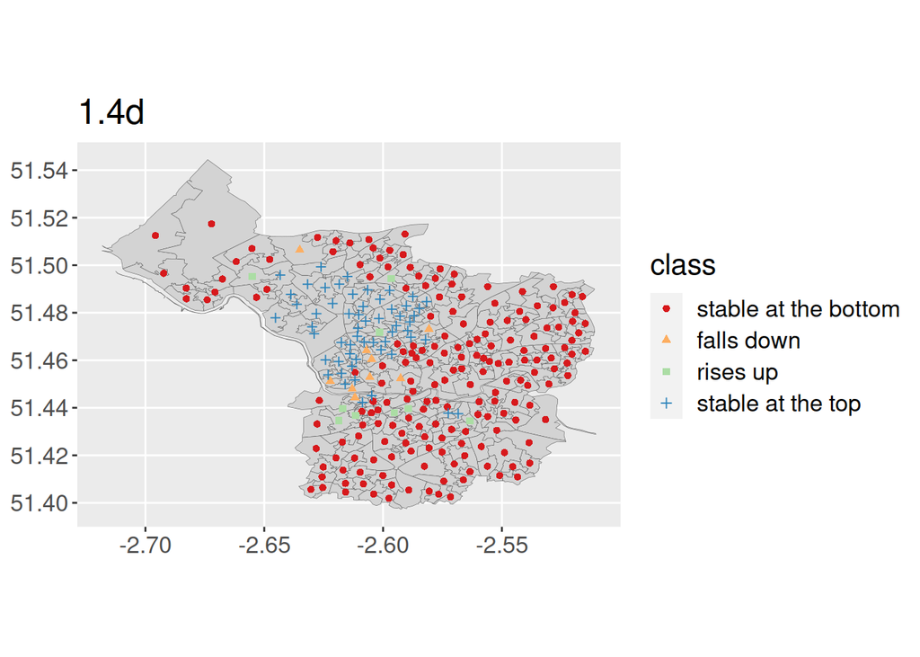

## 1.5

This shows the distribution of house prices in each year.

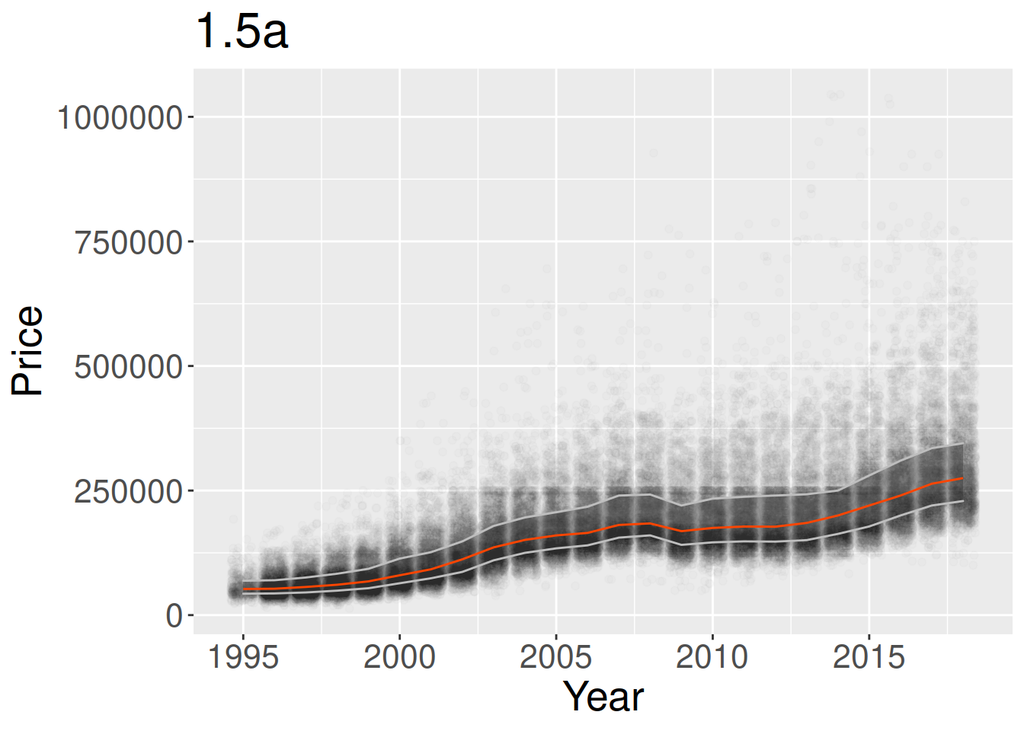

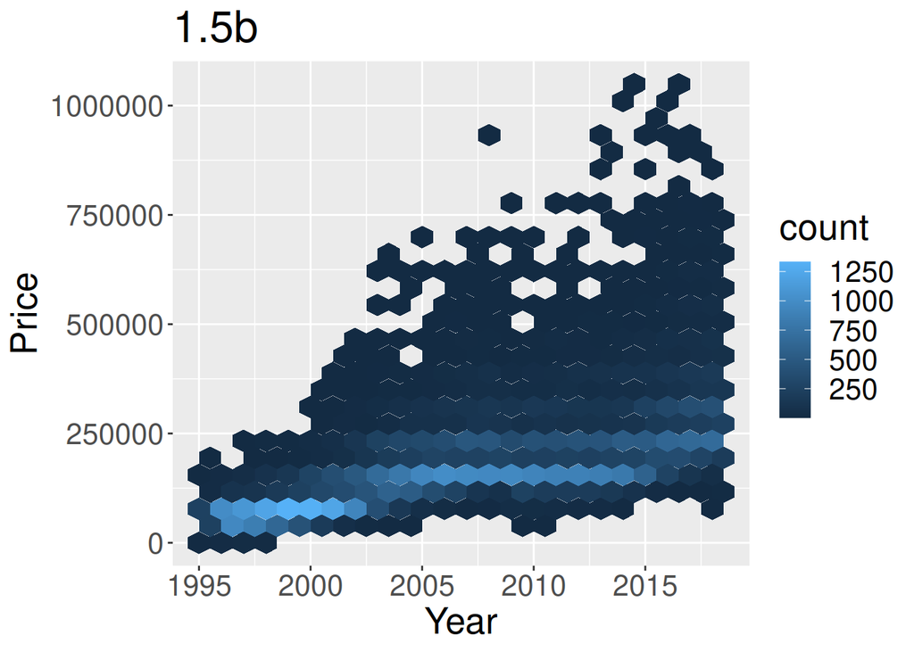

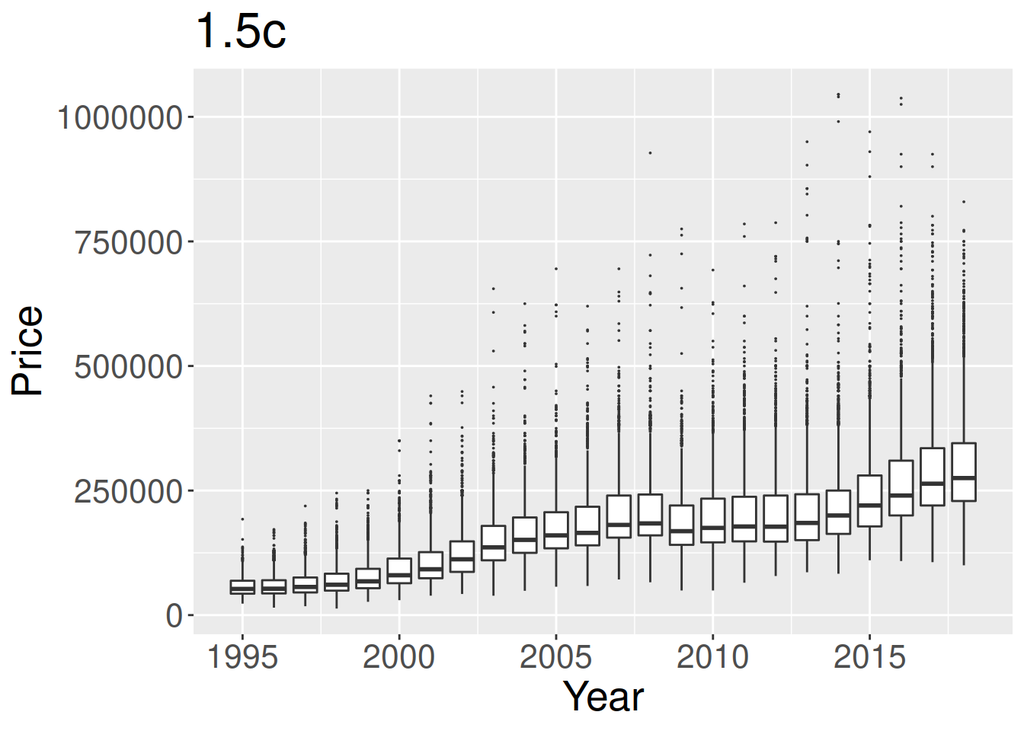

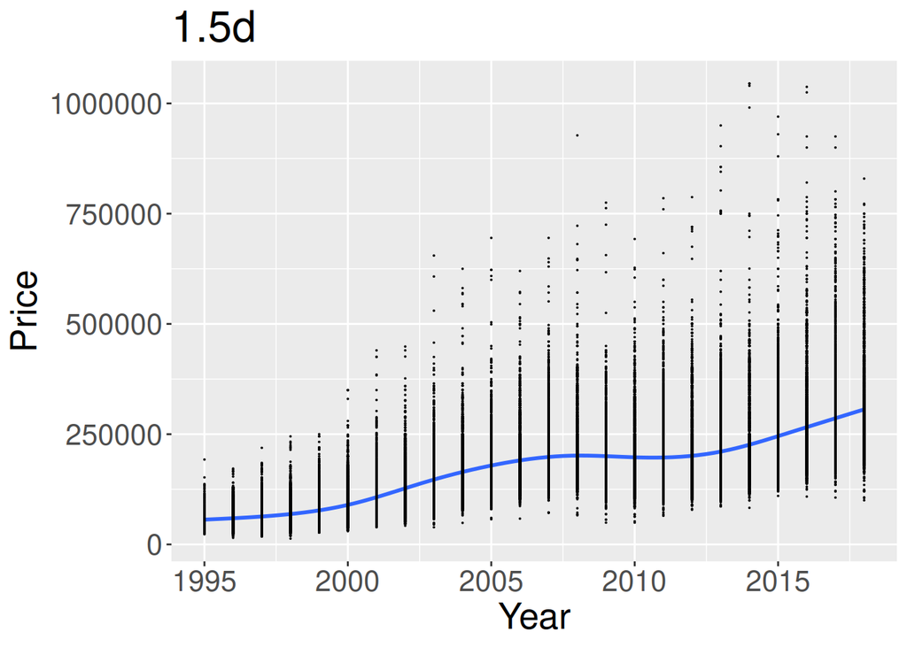

# 2 Making Plots

For each question, make a plot that you think best illustrates the claim. Be mindful of showing only relevant detail, and of the message “at a glance” from the plot.

## 2.1 In the `temps` data, temperature has increased over time.

## 2.2 In the `earnings` data, there are no clear differences in the distributions of height over education levels.

## 2.3 In the `earnings` data, there is a strong relationship between height and earnings.

## 2.4 In the `weca` data, the variability of prices has increased over time.

## 2.5 In the `weca` data, the geographical pattern of prices in Bristol is the same in 2016 as 2017.